# Amazon Alexa Products Analysis

Patrick Chao

## Brief Overview

Amazon is well-known for selling products on its website. For this analysis, we'll be focusing on Amazon Alexa products (basically those that has a virtual assistant AI named Alexa), including products like the Amazon Echo, Amazon TV Sticks, etc. We'll analyze a dataset containing reviews of these Amazon Alexa products and observe what customers think about the products.

## Outline of Analysis:

1. Get a high level understanding of the data (shape, columns, data types, range of fields, etc.)
2. Looking at ratings and reviews by quantity or average
3. Observing variations of products
4. Comparing length of reviews vs. ratings
5. Getting a closer look into what reviews are saying

# Part 1: Understanding the data

## The data

| Column | Definition |
| --- | --- |
| rating | Rating of the product on a 5-star rating sytem |
| date | Date of the review |
| variation | Variant of the product |
| verified_reviews | Customer's review of the product |
| feedback | 0 if negative review, 1 if positive review |

Importing the packages needed:

```r
library(tidyverse)
library(RColorBrewer) # color palettes
library(tidytext)
library(wordcloud)
library(grid) # grid packages to plot side-by-side plots
library(gridExtra)
library(lubridate) # for working with date objects
```

Loading the data:

```r
# read and store data into the DataFrame
df <- read.csv("amazon_alexa.tsv", sep = "\t")

# transforming the field verified_reviews into character
df <- transform(df, verified_reviews = as.character(verified_reviews))
```

Here, we will get ourselves familiar with the data by exploring how many rows and columns there are, the variable types, etc.

```r
# taking a look at the dataset
glimpse(df)
```

```
## Rows: 3,150
## Columns: 5
## $ rating           <int> 5, 5, 4, 5, 5, 5, 3, 5, 5, 5, 5, 5, 5, 5, 5, 5, 5, 5…
## $ date             <fct> 31-Jul-18, 31-Jul-18, 31-Jul-18, 31-Jul-18, 31-Jul-1…
## $ variation        <fct> Charcoal Fabric , Charcoal Fabric , Walnut Finish , …
## $ verified_reviews <chr> "Love my Echo!", "Loved it!", "Sometimes while playi…
## $ feedback         <int> 1, 1, 1, 1, 1, 1, 1, 1, 1, 1, 1, 1, 1, 1, 1, 1, 1, 1…
```

There are 3150 rows and 5 columns in our dataset.

Next, let's check some of the rows of our data and the summary statistics of the entire dataset.

```r
head(df,3) # first 3 rows
```

```
##   rating      date        variation
## 1      5 31-Jul-18 Charcoal Fabric
## 2      5 31-Jul-18 Charcoal Fabric
## 3      4 31-Jul-18   Walnut Finish
##                                                                                                                                                                                      verified_reviews
## 1                                                                                                                                                                                       Love my Echo!
## 2                                                                                                                                                                                           Loved it!
## 3 Sometimes while playing a game, you can answer a question correctly but Alexa says you got it wrong and answers the same as you.  I like being able to turn lights on and off while away from home.
##   feedback
## 1        1
## 2        1
## 3        1
```

```r
tail(df,3) # last 3 rows
```

```
##      rating      date  variation
## 3148      5 30-Jul-18 Black  Dot
## 3149      5 30-Jul-18 White  Dot
## 3150      4 29-Jul-18 Black  Dot
##                                                                                                                                                                                                                                                                                                          …
## 3148 I do love these things, i have them running my entire home, TV, all my lights, my thermostat, my front door dead bolt, the cameras... and i love listening to npr. these things are well worth the value and they really shine once you stat adding smart devices and you can control your entire ho…
## 3149                                                              Only complaint I have is that the sound quality isn't great. I mostly use it for commands though, and I have another dot hooked up to my stereo system to play music through. I have a couple friends that have a dot and don't mind th…
## 3150                                                                                                                                                                                                                                                                                                     …
##      feedback
## 3148        1
## 3149        1
## 3150        1
```

```r
# summary statistics of data
summary(df)
```

```
##      rating             date                             variation
##  Min.   :1.000   30-Jul-18:1603   Black  Dot                  : 516
##  1st Qu.:4.000   29-Jul-18: 482   Charcoal Fabric             : 430
##  Median :5.000   28-Jul-18: 250   Configuration: Fire TV Stick: 350
##  Mean   :4.463   26-Jul-18:  85   Black  Plus                 : 270
##  3rd Qu.:5.000   31-Jul-18:  81   Black  Show                 : 265
##  Max.   :5.000   25-Jul-18:  43   Black                       : 261
##                  (Other)  : 606   (Other)                     :1058
##  verified_reviews      feedback
##  Length:3150        Min.   :0.0000
##  Class :character   1st Qu.:1.0000
##  Mode  :character   Median :1.0000
##                     Mean   :0.9184
##                     3rd Qu.:1.0000
##                     Max.   :1.0000
##
```

Just by observing the summary statistics, we see that the mean of the rating and feedback are quite high. We will observe this further in our exploratory data analysis later.

```r
# check unique values of rating
unique(df['rating'])
```

```
##     rating
## 1        5
## 3        4
## 7        3
## 47       2
## 142      1
```

Ratings on this data only take in whole number values from 1 through 5. Note that the index number just represents the index of the row where each unique rating is first encountered in the dataset.

Now, is there any association between rating and feedback? As noted, a value of 0 for feedback means that the feedback as negative, and a value of 1 for feedback indicates a positive feedback.

```r
# find the minimum and maximum rating for each type of feedback
df %>% select(rating, feedback) %>% group_by(feedback) %>% summarise(minimum_rating = min(rating), maximum_rating = max(rating))
```

```
## # A tibble: 2 x 3
##   feedback minimum_rating maximum_rating
## *    <int>          <int>          <int>
## 1        0              1              2
## 2        1              3              5
```

It seems that negative feedbacks only have ratings of either a 1 or a 2, and positive feedbacks have ratings of 3 or higher.

Next, let's check the range of dates of the date field.

```r
# grab the earliest and latest date
df %>% select(date) %>% summarise(earliest_date = min(dmy(df$date)), latest_date = max(dmy(df$date)))
```

```
##   earliest_date latest_date
## 1    2018-05-16  2018-07-31
```

The range of dates of the entire dataframe are all in the year 2018 from the months of May to July.

```r
# check for missing values
sum(is.na(df))
```

```
## [1] 0
```

There are no missing values on the data, so we do not have to worry about working with them.

## Adding columns

Currently our dataset is pretty limited in terms of the amount of variables it has. However there are some features we can extract out of the existing variables and add on to our dataframe that we can use for our analysis later on. We'll start with estimating the length of each of the reviews.

```r
# save function that splits each word in each review
word_split <- strsplit(df$verified_reviews, split=" ")

# calculate length of amount of words in each review and
# add to a new column called review_length
df$review_length <- sapply(word_split, length)

# looking at data
glimpse(df)
```

```
## Rows: 3,150
## Columns: 6
## $ rating           <int> 5, 5, 4, 5, 5, 5, 3, 5, 5, 5, 5, 5, 5, 5, 5, 5, 5, 5…
## $ date             <fct> 31-Jul-18, 31-Jul-18, 31-Jul-18, 31-Jul-18, 31-Jul-1…
## $ variation        <fct> Charcoal Fabric , Charcoal Fabric , Walnut Finish , …
## $ verified_reviews <chr> "Love my Echo!", "Loved it!", "Sometimes while playi…
## $ feedback         <int> 1, 1, 1, 1, 1, 1, 1, 1, 1, 1, 1, 1, 1, 1, 1, 1, 1, 1…
## $ review_length    <int> 3, 2, 39, 34, 1, 32, 78, 40, 2, 19, 15, 32, 57, 3, 4…
```

Next, we will extract the month and day of the week of each observation and add these to our dataframe.

```r
# get the month of each observation as an integer
month_number <- month(dmy(df$date))

# get month names and store as new column into df
df$month <- month.name[month_number]

# get the day of the week of each observation and store
# as a new column
df$day_of_week <- as.character(wday(dmy(df$date), label=TRUE))

# looking at data
glimpse(df)
```

```
## Rows: 3,150
## Columns: 8
## $ rating           <int> 5, 5, 4, 5, 5, 5, 3, 5, 5, 5, 5, 5, 5, 5, 5, 5, 5, 5…
## $ date             <fct> 31-Jul-18, 31-Jul-18, 31-Jul-18, 31-Jul-18, 31-Jul-1…
## $ variation        <fct> Charcoal Fabric , Charcoal Fabric , Walnut Finish , …
## $ verified_reviews <chr> "Love my Echo!", "Loved it!", "Sometimes while playi…
## $ feedback         <int> 1, 1, 1, 1, 1, 1, 1, 1, 1, 1, 1, 1, 1, 1, 1, 1, 1, 1…
## $ review_length    <int> 3, 2, 39, 34, 1, 32, 78, 40, 2, 19, 15, 32, 57, 3, 4…
## $ month            <chr> "July", "July", "July", "July", "July", "July", "Jul…
## $ day_of_week      <chr> "Tue", "Tue", "Tue", "Tue", "Tue", "Tue", "Tue", "Tu…
```

# Part 2: Measuring Ratings and Reviews

**How are the ratings distributed for Amazon products? Which rating occurs most often?**

Let's start by looking at a bar chart of the ratings to see what people think of Amazon Alexa products.

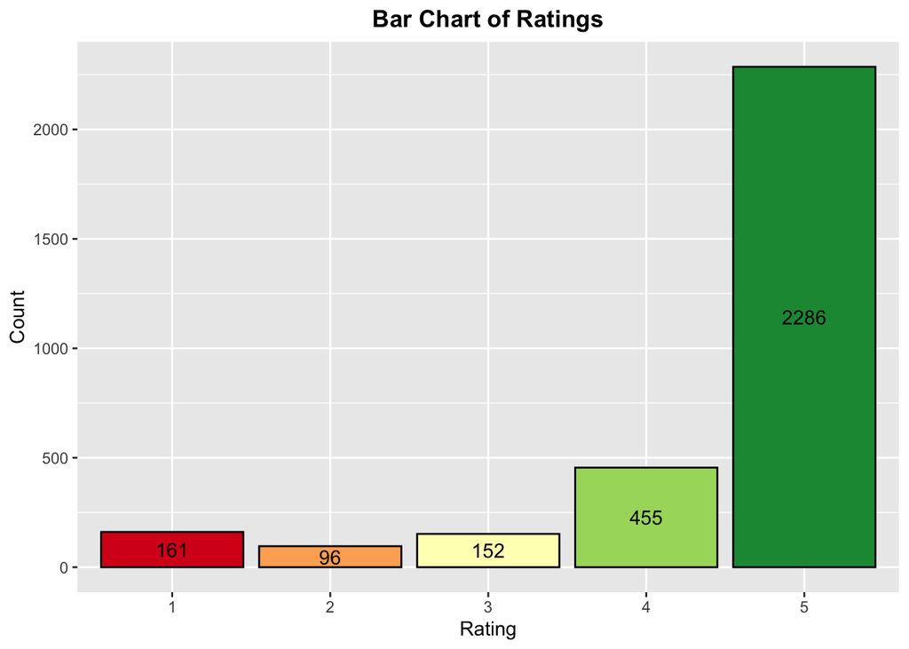

```r
# bar chart of ratings
ggplot(data=df, aes(x=factor(rating), fill=factor(rating))) +
  geom_bar(color='black') +
  geom_text(stat='count', aes(label=..count..), position=position_stack(0.5)) +
  labs(x="Rating", y="Count") +
  ggtitle("Bar Chart of Ratings") +
  scale_fill_brewer(palette='RdYlGn') +
  theme(legend.position = "none", plot.title = element_text(hjust = 0.5, face="bold"))
```

We can further break this down by type of feedback. According to Amazon, 4 and 5 star ratings are considered "positive" feedback, 3 star ratings are considered "neutral" feedback, and 1 and 2 star ratings are considered "negative" feedback on Amazon.

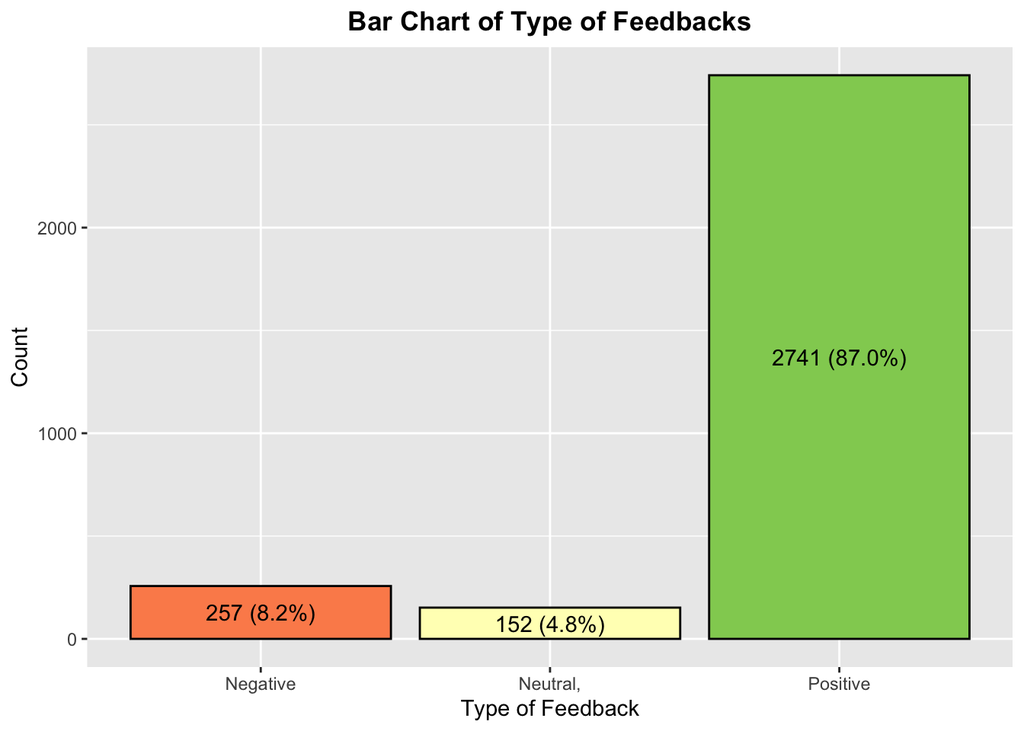

```r
# create x axis tick labels
xlabels <- c("Negative","Neutral,","Positive")

# bar chart by type of feedbacks
df %>% mutate(cuts = cut(rating, c(0, 2, 3, Inf))) %>%
ggplot(aes(x=factor(cuts), fill=factor(cuts))) +
  geom_bar(color='black') +
  geom_text(stat='count', aes(label=paste0(..count..," (", c("8.2","4.8","87.0"), "%)")), position=position_stack(0.5)) +
  labs(x="Type of Feedback", y="Count") +
  ggtitle("Bar Chart of Type of Feedbacks") +
  scale_x_discrete(labels= xlabels) +
  scale_fill_brewer(palette='RdYlGn') +
  theme(legend.position = "none", plot.title = element_text(hjust = 0.5, face="bold"))
```

There is a large number of people who rated Amazon products with a 5 star rating. About 87% of customers who reviewed the products were satisfied with their products.

**How often were reviews written on each month and each day of the week?**

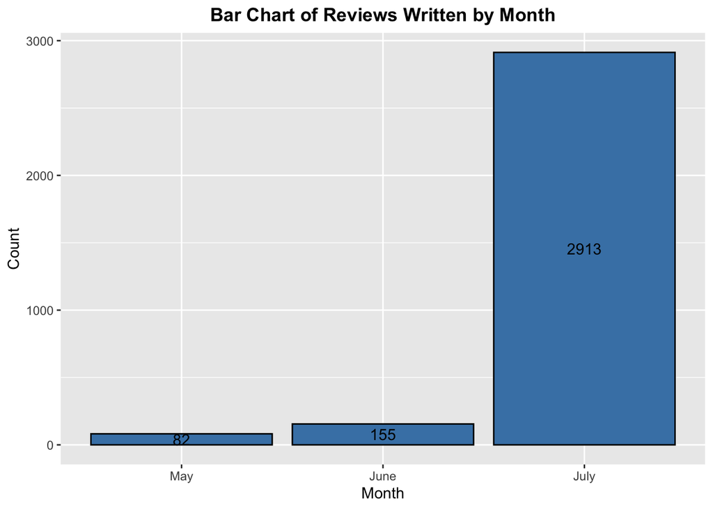

```r
# bar chart of reviews by month
ggplot(data=df, mapping = aes(x=factor(month, level= c('May','June','July')), fill=month)) +
  geom_bar(color='black',fill='steelblue') +
  geom_text(stat='count', aes(label=..count..), position=position_stack(0.5)) +
  labs(x="Month", y="Count") +
  ggtitle("Bar Chart of Reviews Written by Month") +
  theme(legend.position = "none", plot.title = element_text(hjust = 0.5, face="bold"))
```

Most of the reviews from the data were written on the month of July. This graph could just have been a result of how the data was originally extracted.

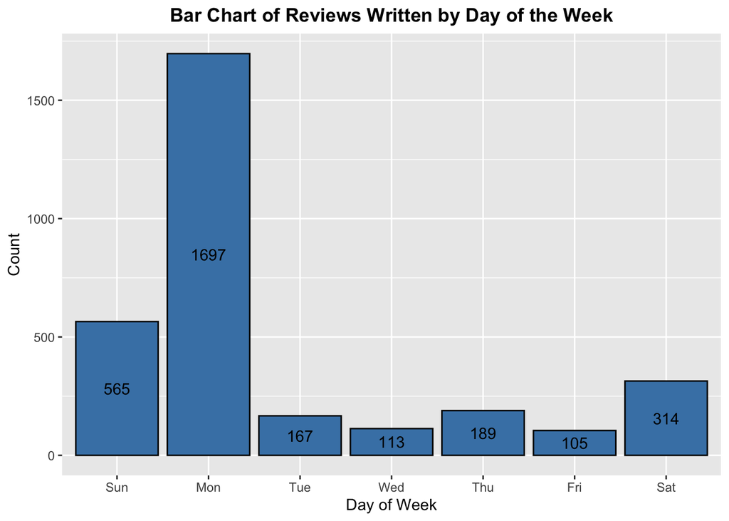

```r
# bar chart of reviews by day of week
ggplot(data=df, mapping = aes(x=factor(day_of_week, level= c('Sun','Mon','Tue','Wed','Thu','Fri','Sat')), fill=day_of_week)) +
  geom_bar(color='black',fill='steelblue') +
  geom_text(stat='count', aes(label=..count..), position=position_stack(0.5)) +
  labs(x="Day of Week", y="Count") +
  ggtitle("Bar Chart of Reviews Written by Day of the Week") +
  theme(legend.position = "none", plot.title = element_text(hjust = 0.5, face="bold"))
```

Most reviews were written on Mondays and Sundays. A plausible explanation for this could be that most people order products on Fridays or during the weekend. And since Amazon guarantees a 2-day delivery date for customers who are members of Amazon Prime, people will write their reviews on Sunday or Monday, the same day they receive their delivery.

**What were the average ratings by month or day of week?**

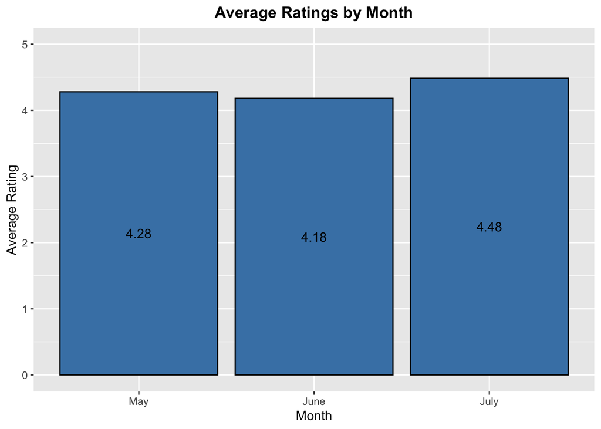

```r
# average ratings by month
df %>%
group_by(month) %>%
summarise(AverageRating = mean(rating)) %>%
  ggplot(aes(factor(month, levels=c('May','June','July')), AverageRating, label=round(AverageRating,2), fill=factor(month))) +
  geom_col(color='black',fill='steelblue') +
  geom_text(position=position_stack(0.5)) +
  labs(x="Month", y='Average Rating') +
  ylim(0,5) +
  ggtitle("Average Ratings by Month") +
  theme(legend.position = "none", plot.title = element_text(hjust = 0.5, face="bold"))
```

The average ratings are quite similar to each other, with ratings from each month being higher than 4.00 and July having the highest rating of all months. Though, we should be careful with comparing July to the other months since July had much more reviews than May and June.

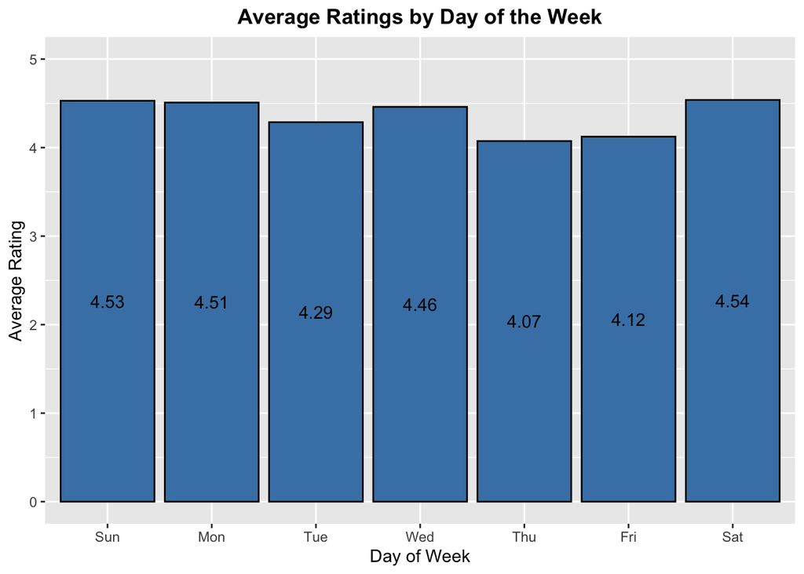

```r
# average ratings by day of week
df %>%
  group_by(day_of_week) %>%
summarise(AverageRating = mean(rating)) %>%
    ggplot(aes(factor(day_of_week, levels=c('Sun','Mon','Tue','Wed','Thu','Fri','Sat')), AverageRating, label=round(AverageRating,2), fill=factor(day_of_week))) +
    geom_col(color='black',fill='steelblue') +
    geom_text(position=position_stack(0.5)) +
    labs(x="Day of Week", y='Average Rating') +
    ylim(0,5) +
    ggtitle("Average Ratings by Day of the Week") +
  theme(legend.position = "none", plot.title = element_text(hjust = 0.5, face="bold"))
```

Average ratings are all above 4.00 and are not too much different from each other. The highest average ratings occur on the weekend, Monday, and Wednesday, where each ratings are around 4.5. Reviews written on Thursdays and Fridays have the lowest average ratings.

# Part 3: Looking at the different variations of Amazon Products

Let's observe if there are any specific variations that customers prefer over the other.

**Which variation are most frequently rated, and which have the highest average rating?**

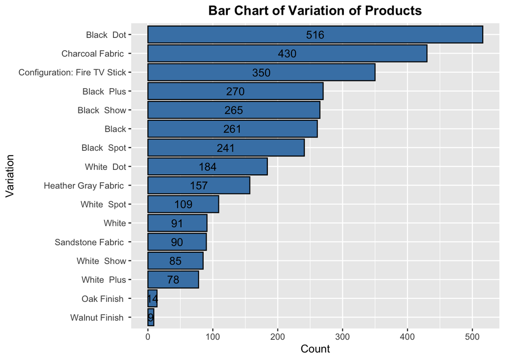

```r
# bar chart for count of variation of products in descending order
ggplot(data=df, aes(x=fct_rev(fct_infreq(variation)), fill=factor(variation))) +
  geom_bar(color='black',fill='steelblue') +
  geom_text(stat='count', aes(label=..count..), position=position_stack(0.5)) +
  coord_flip() +
  labs(x="Variation", y="Count") +
  ggtitle("Bar Chart of Variation of Products") +
  theme(legend.position = "none", plot.title = element_text(hjust = 0.5, face="bold"))
```

The bar chart shows that customers in the dataset have mostly bought black-colored products.

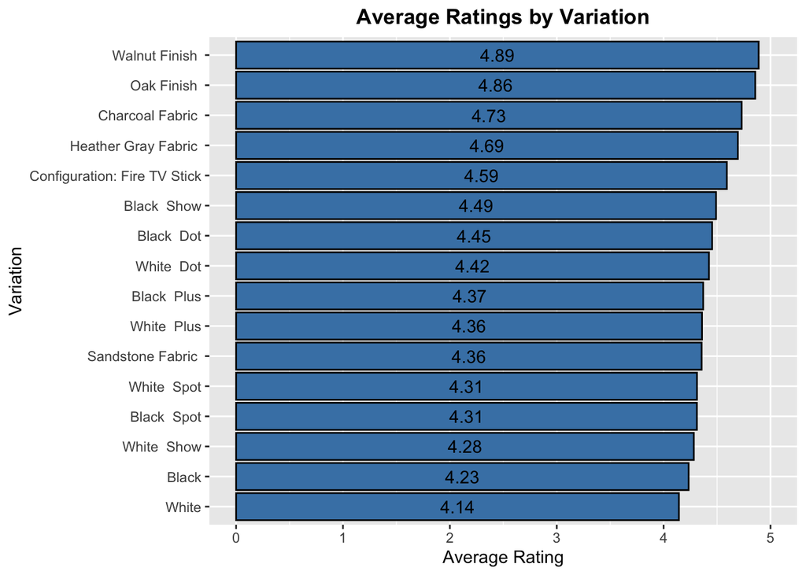

```r
# bar chart for average rating of variation of products in descending order
df %>%
  group_by(variation) %>%
  summarise(AverageRating = mean(rating)) %>%
    ggplot(aes(factor(variation), AverageRating, label=round(AverageRating,2), fill=factor(variation))) +
    geom_col(color='black',fill='steelblue', aes(reorder(variation,AverageRating),AverageRating)) +
    geom_text(position=position_stack(0.5)) +
    coord_flip() +
  labs(x="Variation", y='Average Rating') +
    ylim(0,5) +
    ggtitle("Average Ratings by Variation") +
    theme(legend.position = "none", plot.title = element_text(hjust = 0.5, face="bold"))
```

All products have average ratings of more than 4.00. Highest average rated products seem to be Walnut Finish and Oak Finish, but note that these products didn't have much reviews to begin with as shown in the bar chart of variation of products. Fabric products are the next highest average rated products and have much more reviews than the Finish products.

# Part 4: Length of Reviews

**What is the distribution of the length of reviews?**

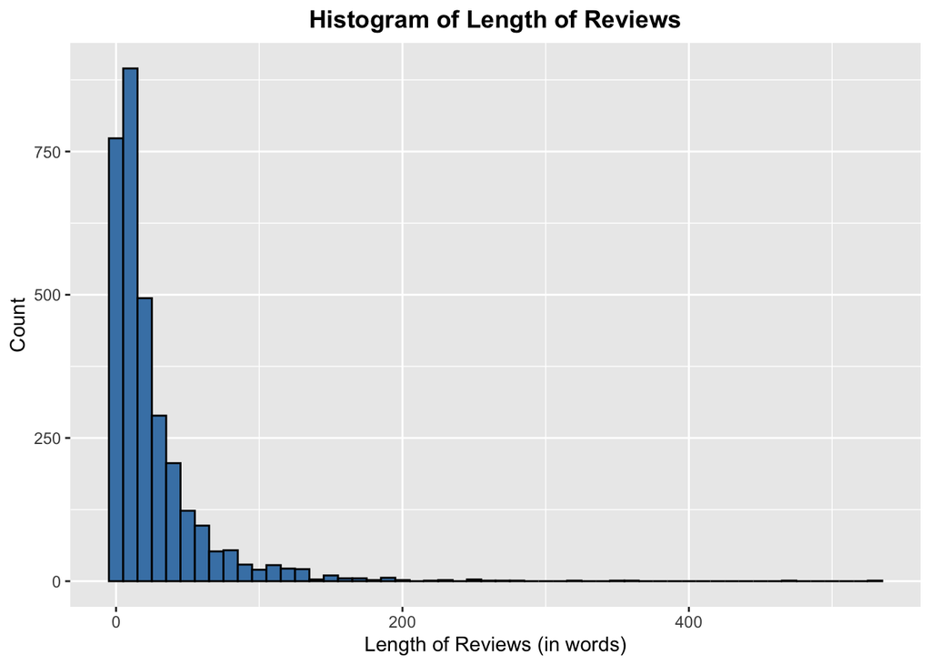

```r
# histogram of length of reviews
ggplot(data=df, aes(x=review_length)) +
  geom_histogram(color='black',fill='steelblue',binwidth=10) +
  labs(x="Length of Reviews (in words)", y='Count') +
  ggtitle("Histogram of Length of Reviews") +
  theme(legend.position = "none", plot.title = element_text(hjust = 0.5, face="bold"))
```

Most reviews seems to be below 50 words, but there are some huge outliers with length of reviews beyond 100 words. We can filter out outliers using the Interquartile Range Rule and plot another histogram to better see the distribution of length of reviews.

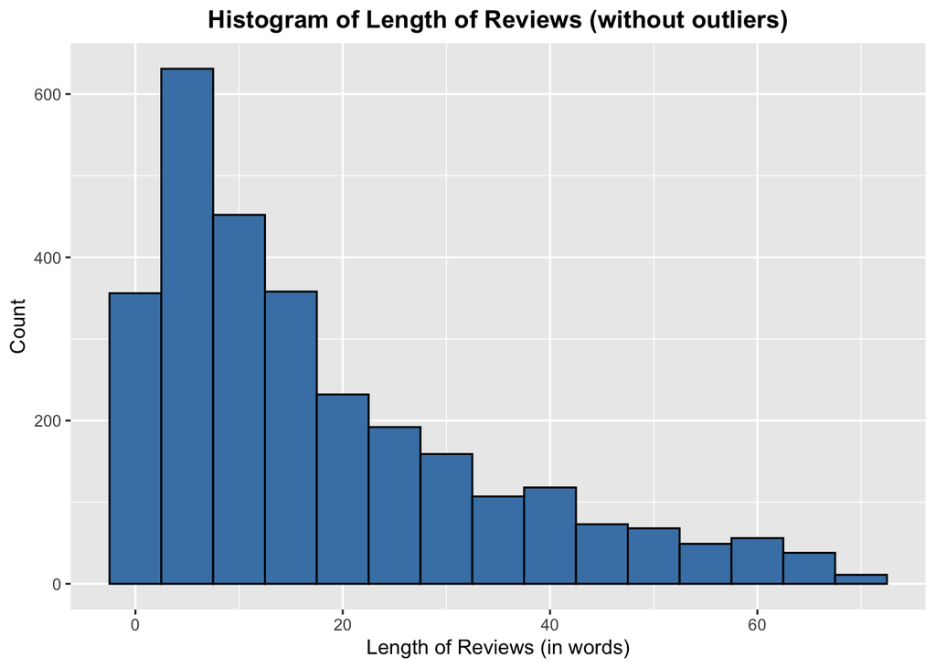

```r
# calculate and store Q1 for review_length
q1 = as.numeric(df %>% summarise(quantile(review_length,probs=0.25)))

# calculate and store Q3 for review_length
q3 = as.numeric(df %>% summarise(quantile(review_length,probs=0.75)))

# calculate and store IQR for review_length
iqr = as.numeric(df %>% summarise(q3-q1))

# plotting histogram of length of reviews without outliers
df %>%
  filter(review_length < (q3 + 1.5 * iqr)) %>%
  ggplot(aes(x=review_length)) +
  geom_histogram(color='black',fill='steelblue',binwidth=5) +
  labs(x="Length of Reviews (in words)", y='Count') +
  ggtitle("Histogram of Length of Reviews (without outliers)") +
  theme(legend.position = "none", plot.title = element_text(hjust = 0.5, face="bold"))
```

We can tell that most reviews are pretty short with word counts of less than 20.

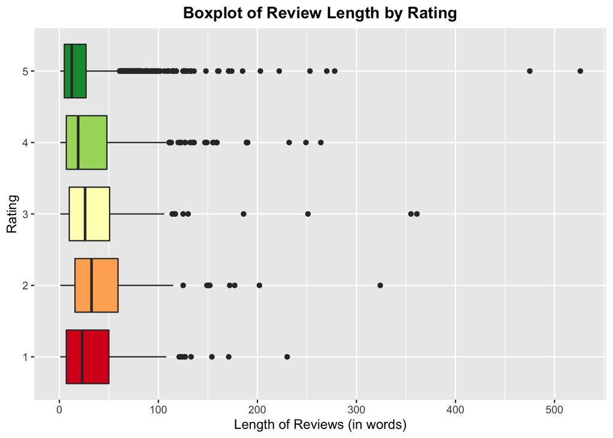

```r
# boxplot of review length by rating
ggplot(data=df, aes(x=as.character(rating),y=review_length,fill=as.factor(rating))) +
  geom_boxplot() +
  coord_flip() +
  scale_fill_brewer(palette='RdYlGn') +
  labs(x="Rating", y='Length of Reviews (in words)') +
  ggtitle("Boxplot of Review Length by Rating") +
  theme(legend.position = "none", plot.title = element_text(hjust = 0.5, face="bold"))
```

Most reviews are short in terms of amount of words it has, regardless of what the rating seems to be. Let's examine the boxplot closer by filtering using the same IQR rule on review length.

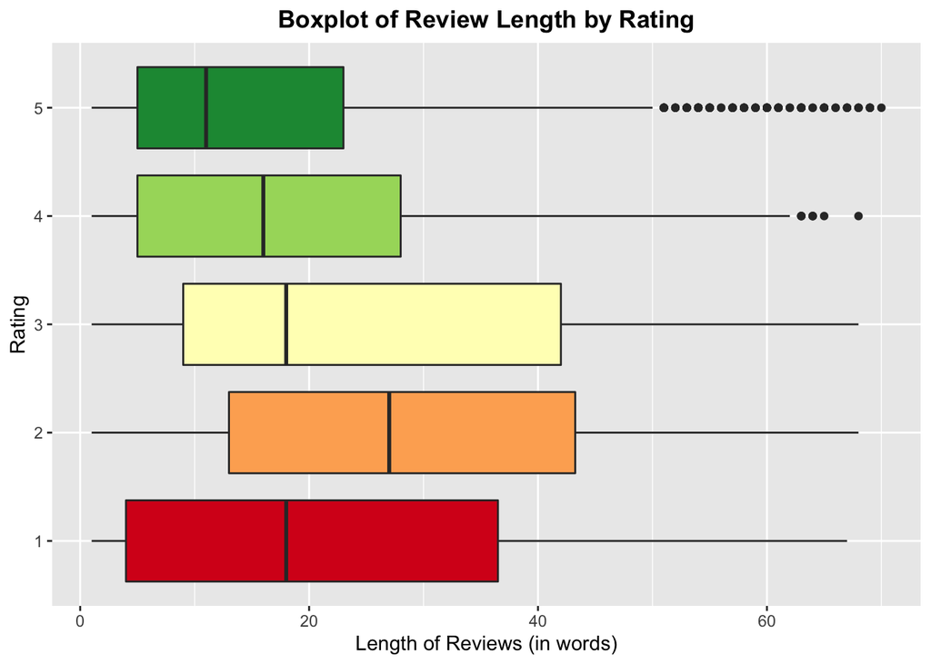

```r
# boxplot of review length by rating
df %>% filter(review_length < (q3 + 1.5 * iqr)) %>%
ggplot(aes(x=as.character(rating),y=review_length,fill=as.factor(rating))) +
  geom_boxplot() +
  coord_flip() +
  scale_fill_brewer(palette='RdYlGn') +
  labs(x="Rating", y='Length of Reviews (in words)') +
  ggtitle("Boxplot of Review Length by Rating") +
  theme(legend.position = "none", plot.title = element_text(hjust = 0.5, face="bold"))
```

Reviews rated with a 2 are generally the longest reviews compared to other reviews. Reviews that have a rating of a 5 tends to be the shortest.

# Part 5: What are reviews saying?

**What are some of the most commonly used words in reviews of Amazon products by positive and negative reviews?**

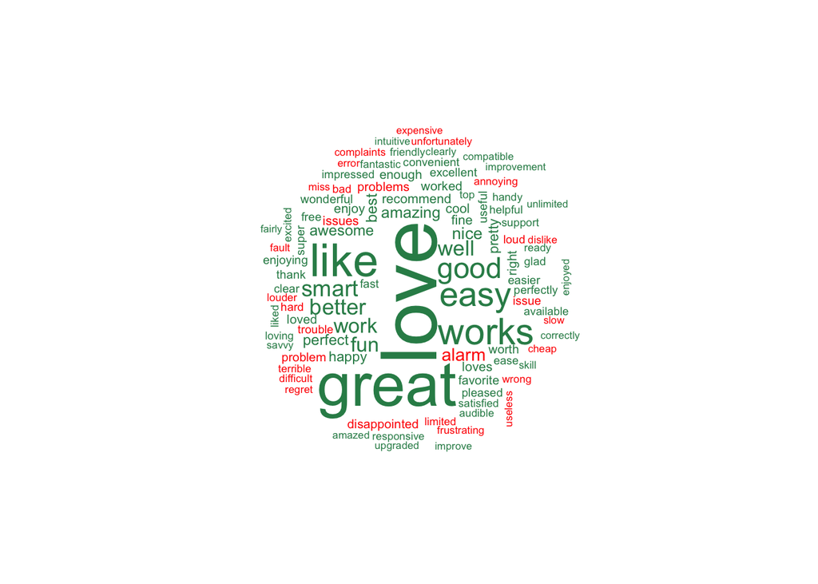

```r
# split the verified_reviews field into words
review_words <- unnest_tokens(df, word, verified_reviews)

# evaluate the opinion/emotion from text using Bing Liu's sentimental analysis
review_sentiment <- review_words %>%
    inner_join(get_sentiments(lexicon = "bing"), by = "word") %>%
    count(word, sentiment) %>%
    mutate(color = ifelse(sentiment == "positive", "seagreen", "red"))

# create a wordcloud for the sentiment of words used in reviews
wordcloud(words = review_sentiment$word, freq = review_sentiment$n, max.words=100, random.order = FALSE, colors = review_sentiment$color, ordered.colors = TRUE)
```

In the word cloud above, the most used words are indicated by size. So larger sized words mean higher counts, and smaller sized words mean lower counts. Also, the words are colored by sentiment where the green-colored words are positive words and red-colored words are negative. For the most part, we can see that Amazon products are liked by customers, where they used words such as "love" and "great" in their reviews.

Let's see the actual numbers by looking at bar charts of the amount of times these words occur.

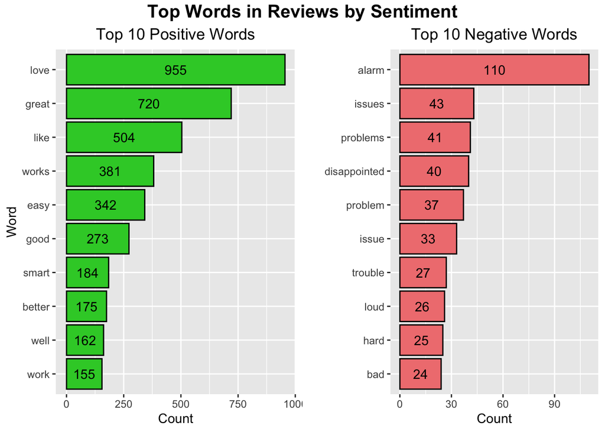

```r
# create a bar chart of top 10 positive words
plot_positive <- review_sentiment %>%
    filter(sentiment == "positive") %>%
    arrange(desc(n)) %>%
    slice(1:10) %>%
    ggplot(aes(x = reorder(word, n), y = n)) +
        geom_col(color = "black", fill='limegreen') +
        geom_text(aes(label = n), position = position_stack(vjust = 0.5)) +
        coord_flip() +
        ggtitle("Top 10 Positive Words") +
        labs(x = "Word", y = "Count") +
        theme(legend.position = "none",
              plot.title = element_text(hjust = 0.5))

# create a bar chart of top 10 negative words
plot_negative <- review_sentiment %>%
    filter(sentiment == "negative") %>%
    arrange(desc(n)) %>%
    slice(1:10) %>%
    ggplot(aes(x = reorder(word, n), y = n)) +
        geom_col(color = "black", fill='lightcoral') +
        geom_text(aes(label = n), position = position_stack(vjust = 0.5)) +
        coord_flip() +
        ggtitle("Top 10 Negative Words") +
        labs(x = "", y = "Count") +
        theme(legend.position = "none",
              plot.title = element_text(hjust = 0.5))

# plot top positive and negative plots side-by-side
grid.arrange(plot_positive, plot_negative, nrow=1, ncol=2, top=textGrob("Top Words in Reviews by Sentiment",gp=gpar(fontsize=15,font=2)))
```

Words like "love" and "great" do indeed take the top spots for most frequently used positive words in reviews, as we speculated from the word cloud. Moreover, these positive words have high counts, so it seems that Amazon products are doing great overall.

If we look at the negative words, we see that there are indeed words that can be considered negative such as "issues" and "problems", but the word "alarm" might be an invalid word to be classified as negative, so this is a word on the bar chart that we should be careful about.

Still, the word counts of negative words are quite low, so there seem to be far less customers who said negative things compared to customers who said positive things about the Amazon products in their reviews.

# Conclusion

Overall, it seems like customers are satisfied with their Amazon Alexa products. We measured the ratings and reviews and observed that most reviews gave a rating of 5. Ratings among the variation of products are quite similar to each other and are all doing well. Generally, lower ratings have higher word counts than higher ratings. Also, many reviews have left positive feelings about the Amazon products indicating that the customers loved and think that the products are great. But there are reviews in the other hand that have given negative feedback saying that the customers has issues or problems and are disappointed with their purchase.